# Stats 220 - Assginment 5

Liam Barnes (lbar177)

2022-06-01

## 1. Introduction

I chose the most recent Apple Top 100 playlist from Australia, New Zealand, the United Kingdom, the United States and Canada. I thought that it would be interesting to compare countries who are very similar (e.g language and culture) to see, in a world which is increasingly interconnected, whether there were significant differences in musical preferences between these nations.

## 2. Data Visualisation

### 2.1 Vulgarity Visualisation

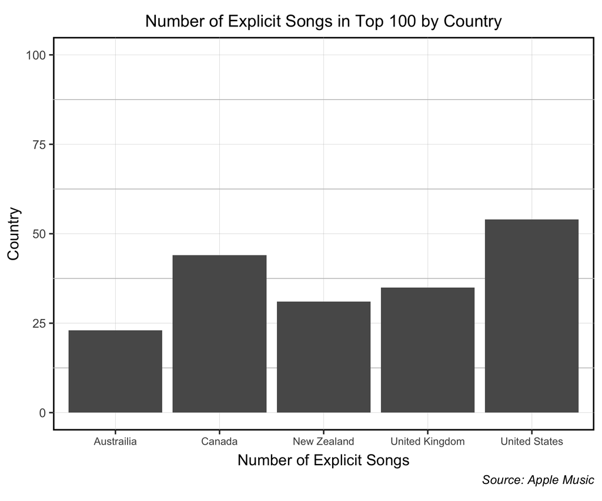

Vulgarity Visualisation

I created a visualisation which compared each nations preference for explicit songs by counting the number of explicit songs in the Top 100. If we are to believe that life imitates art, this visualisation provides an insight into the way in which different groups of people communicate - some nations are more abrasive (as shown through their preference or at least lack of disdain for the use of explicit language) while others are more tempered.

### 2.2 International Comparisons

#### 2.2.1 Positional Similarity

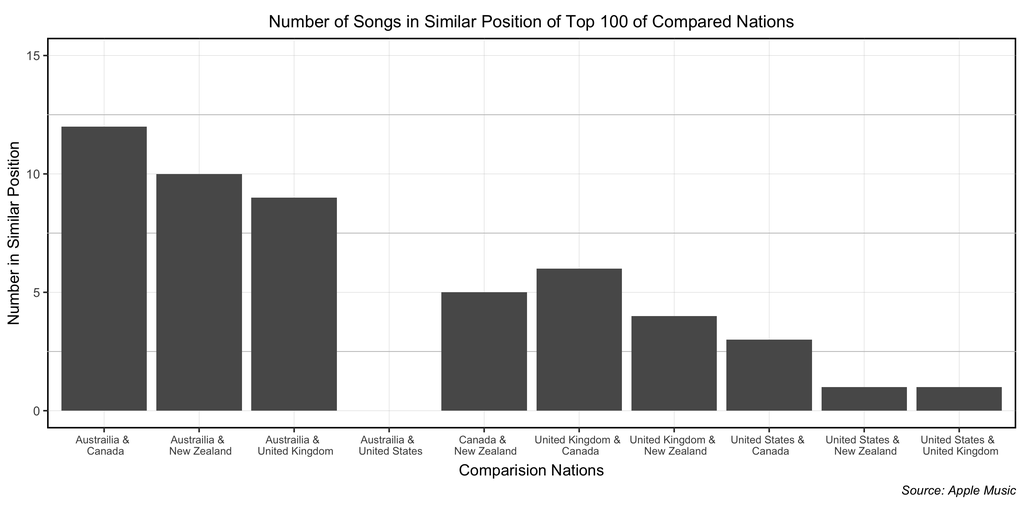

#### 2.2.2 List-Wide Similarity

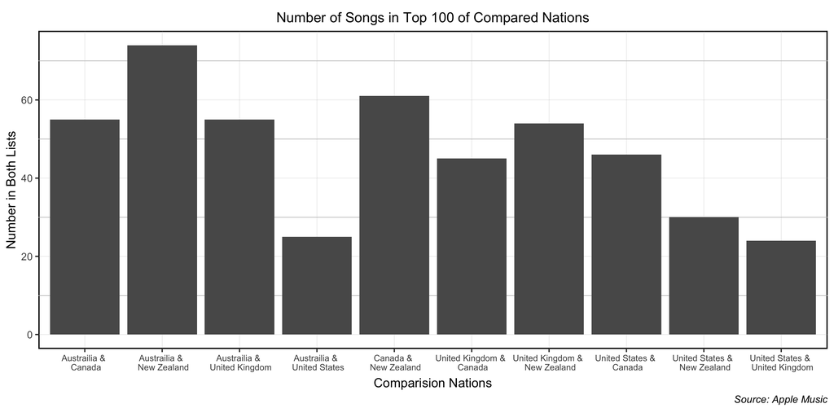

#### 2.2.3 Comparisons Overview

As a result of PART E (data creativity) I have created two charts which compare the similarity of the Top 100 charts between nations in the anglosphere. The first chart compares the number of songs which are in a similar position (+/- 1) on the charts of two different countries between different pairs of countries. The second chart compares the number of songs on the lists of both of a pair of countries between different pairs of countries.

These two charts together represent the most compelling way to compare musical preferences between nations and make a further determination as to what nations are similar and conversely, which are not. For example, we can see that in terms of the songs within the Top 100, New Zealand and Australia are very similar.

## 3. Data Creation

I have created a number of different charts and tables throughout the course of analysing this data; the following is an explanation of how this analysis has used a range of different tools from the STATS220 course.

### 3.1 General

In order to conduct any meaningful data analysis, I first had to collect the data to analyse, to do this I first categorised my data by country in a CSV file, I then used both the rvest package and web scraping techniques alongside querying an API to gather the relevant data. I then combined this data using a R join function to create one large data set that I could draw from.

### 3.2 Positional

I created an algorithm to determine whether a song was in a similar position on the Top 100 list of two different countries. I then compared every country to every other country.

In order to compare the position of each country I filtered the data set to segment the data by country and then used the map_df function to iterate over the list and compare the position of songs. I then counted the number of matches in the list. This data could then be plotted using ggPlot2.

### 3.3 List-Wide

I created an algorithm to determine whether a song was in the Top 100 list of two different countries. I then compared every country to every other country.

In order to conduct the list-wide analysis I needed to iterate over each list and compare it to the songs in every other list and then count the matches. It is worthwhile to note here that as with the positional data set it was important that I was conducting this analysis efficiently as there were a significant number of comparisons to be made as such I wrote an algorithm with would sample without replacement to ensure that I wasn’t doing comparisons more than once. This data could then be plotted using ggPlot2.

### 3.4 Vulgarity

I created a tibble which compared the number of explicit tracks in the Top 100 of each country.

Creating the vulgarity comparison was much more straightforward than the positional and list-wide comparisons as it simply required me to filter by the listed country and then count the number of explicit tracks which I then displayed using the summarise function. This data could then be plotted using ggPlot2.

### 3.5 Time / Price

I created a tibble which compared the mean song length and median price between all countries.

Do analyse the song length and pricing data by country I ensured that I removed any NA values from the data, used the group_by function to separate by country and then use the summarise and relevant analytic function to do the analysis which I could then display as a tibble (though chose not to)

### 3.6 Harry Songs

I created a data frame which contained a number of songs preformed by Harry Styles (as a Solo-artist) this could be very useful for analysis the popularity of Harry’s songs. e.g by comparing it to Top 100 lists.

## 4. Final Reflection

### 4.1 General Reflection

One important idea that I have learnt from module 5 is how we can scrape data. Sometimes we do not have traditional data collection tools (e.g surveys, studies) available to us nor a preexisting dataset, web scraping is an effective way in which to curate existing data. There are a number of important considerations when web-scraping, including; attempting to scrape elements which are unlikely to change to ensure your scraping is robust and less likely to be effected by changes to the website and secondly ensuring that you are scraping data ethnically, this means by complying with the terms of service of the website (and the robot.txt file) and not overloading the website with requests.

While this course has covered a substantial breadth of content, I think that the most important thing I have learnt is how to manipulate data in such a way that I can draw insights from that data. This includes everything from filtering and sub-setting data to mutating columns to joining tables together to draw insights from a larger pool of data.

I am particularly interested how we can further automate the data-collection process particularly in the context of web-scraping. I am additionally interested how I can protect my own data on my websites from being scraped when I do not want it to be.

### 4.2 Redemption

1. **Mark Lost:** In assignment 1, I failed to create a github page. **Redemption:** I have created a github page here: https://liam-barnes.github.io/Stats220A5/ which contains everything in this index.html and therefore acts as an alternative way of accessing the body of my assignment.
2. **Mark Lost:** In assignment 3, when querying the Google Books database I failed to query based upon the specified query metric title. **Redemption:** In querying the itunes database for songs related to the search term Harry Styles, I ensured that the search term was correct and that I was only searching for music as I was only interested in songs, I then filtered the data such that I had songs where Harry Styles was a solo-artist.
3. **Mark Lost:** In assignment 3, in calculating aggregates I failed to omit NA values. **Redemption:** In calculating the mean track time and median track price of different nations, I ensured to omit any NA values using the na.rm = TRUE argument. I then stored this data in nationalSummaryData for potential future analysis.

## 5. Code Appendix

### 5.1 Web-scraping

```r
library(tidyverse)
library(rvest)

urls = read.csv("top100s.csv")

apple_data = map_df(1 : length(urls$Country), function(i) {
  Sys.sleep(2)

  url = urls$URL[i]
  page = read_html(url)

  trackId=page %>%
    html_elements(".songs-list") %>%
    html_elements("a") %>%
    html_attr("href") %>%
    .[str_detect(., "/song/")] %>%
    str_remove_all("https://music.apple.com/us/song/")

  scrapedTrackName = page %>%
    html_elements(".songs-list-row__song-name") %>%
    html_text2()

  trackRank = page %>%
    html_elements(".songs-list-row__rank") %>%
    html_text2()

  return(tibble(trackId, trackRank, scrapedTrackName, urls$Country[i], Sys.Date()))
})

apple_data = rename(apple_data, rankedCountry = 4, dateRetrived = 5)

saveRDS(apple_data, "apple_data.rds")
```

### 5.2 API Call

```r
library(tidyverse)
library(jsonlite)

apple_data = readRDS("apple_data.rds")

trackIds <- apple_data$trackId %>%
  unique() %>%
  na.omit()

itunes_data = map_df(1 : length(trackIds), function(i){
  Sys.sleep(2)

  song_id <- trackIds[i]

  url <- paste0("https://itunes.apple.com/lookup?id=", song_id)
  response <- fromJSON(url)
  structured_response <- response$results

  return(tibble(structured_response))
})

saveRDS(itunes_data, "itunes_data.rds")
```

### 5.3 Data Combination

```r
library(tidyverse)

itunes_data = readRDS("itunes_data.rds")
apple_data = readRDS("apple_data.rds")

itunes_data$trackId = as.character(itunes_data$trackId)

song_data = inner_join(apple_data, itunes_data, by = "trackId")

# For Additional Inspection in Excel
write.csv("data_inspection.csv", row.names = FALSE)

saveRDS(song_data, "song_data.rds")
```

### 5.4 Data Visualisation

```r
library(tidyverse)
library(ggplot2)

song_data = readRDS("song_data.rds")

# Data Manipulation
explicitnessData = song_data %>%
  filter(trackExplicitness == "explicit") %>%
  group_by(rankedCountry) %>%
  summarise(noExplicit = length(trackExplicitness))

# Visualisation
explicitnessChart = ggplot(explicitnessData) +
  geom_col(aes(x = rankedCountry, y = noExplicit)) +
  labs(title = "Number of Explicit Songs in Top 100 by Country",
       x = "Number of Explicit Songs",
       y = "Country",
       caption = "Source: Apple Music") +
  theme(plot.title = element_text(hjust = 0.5,
                                  size = 12,
                                  face = "plain",
                                  margin = margin(t = 5, r = 5, b = 5, l = 5, unit = "pt")),
        plot.caption = element_text(hjust = 1,
                                    face = "italic",
                                    margin = margin(t = 5, r = 5, b = 5, l = 5, unit = "pt")),
        axis.title.x = element_text(margin = margin (t = 5)),
        axis.text.x = element_text(size = 7.5),
        panel.background = element_rect(fill = "white", colour = "black", size = 1),
        panel.grid.major = element_line(colour = "grey", size = 0.075),
        panel.grid.minor = element_line(colour = "grey")) +
  ylim(0, 100)

ggsave("song_vis.png",
       plot = explicitnessChart,
       width = 6,
       height = 5,
       units = "in")
```

### 5.5 Further Analysis

```r
library(tidyverse)
library(dplyr)
library(ggplot2)
library(jsonlite)

song_data = readRDS("song_data.rds")

countries = song_data$rankedCountry %>% unique()

# Group Similarity Comparisons into 1 function
samenessComparisons = function(comparisonSetA, comparisonSetB) {
  # Positional Similarity - split out for clarity
  multipleComparisons = function(primaryText, secondaryList, currentIteration) {
    return(primaryText == secondaryList[(currentIteration - 1) : (currentIteration + 1)])
  }

  similarPosition = map_df(1 : 100, function(i){
    truthness = multipleComparisons(comparisonSetA$trackName[i], comparisonSetB$trackName, i)
    return(tibble(truthness))
  }) %>% na.omit()

  noSimilar = as.numeric(count(filter(similarPosition, truthness == TRUE)))

  # In List Comparison
  inList = map_df(1 : 100, function(i){
    truthness = comparisonSetA$trackName[i] == comparisonSetB$trackName
    return(tibble(comparisonSetA$trackName[i], truthness))
  }) %>% unique()

  noInList = as.numeric(count(filter(inList, truthness == TRUE)))

  comparisonGroups = paste(comparisonSetA$rankedCountry, comparisonSetB$rankedCountry, sep = " & \n ")

  similarity = tibble(comparisonGroups, noInList, noSimilar) %>%
    unique()
  return(similarity)

}

# Created for readability
nationData = function(nation) {
  return(filter(song_data, rankedCountry == nation))
}

compareAll = map_df(1 : length(countries), function(i){
  allCountriesIndex = c((i):length(countries))
  countriesExcludingSelf = allCountriesIndex[allCountriesIndex != i]

  nationComparison = map_df(countriesExcludingSelf, function(s){
    individualComparison = samenessComparisons(nationData(countries[i]), nationData(countries[s]))
    return(individualComparison)
    print(s)
  })

  return(nationComparison)
})

# Data Visualisation
# Theme Setup
liamsTheme = theme(plot.title = element_text(hjust = 0.5,
                                             size = 12,
                                             face = "plain",
                                             margin = margin(t = 5, r = 5, b = 5, l = 5, unit = "pt")),
                   plot.caption = element_text(hjust = 1,
                                               face = "italic",
                                               margin = margin(t = 5, r = 5, b = 5, l = 5, unit = "pt")),
                   axis.title.x = element_text(margin = margin (t = 5)),
                   axis.text.x = element_text(size = 7.5),
                   panel.background = element_rect(fill = "white", colour = "black", size = 1),
                   panel.grid.major = element_line(colour = "grey", size = 0.075),
                   panel.grid.minor = element_line(colour = "grey"))

# Plot Creation
noInListPlot = ggplot(compareAll) +
  geom_col(aes(x = comparisonGroups, y = noInList)) +
  liamsTheme +
  labs(title = "Number of Songs in Top 100 of Compared Nations",
       x = "Comparision Nations",
       y = "Number in Both Lists",
       caption = "Source: Apple Music")
  ylim(0, 80)

noSimilarPlot = ggplot(compareAll) +
  geom_col(aes(x = comparisonGroups, y = noSimilar)) +
  liamsTheme +
  labs(title = "Number of Songs in Similar Position of Top 100 of Compared Nations",
       x = "Comparision Nations",
       y = "Number in Similar Position",
       caption = "Source: Apple Music") +
  ylim(0, 15)

# Save the plots for use in markdown

ggsave("song_comparison1.png",
       plot = noInListPlot,
       width = 10,
       height = 5,
       units = "in")

ggsave("song_comparison2.png",
       plot = noSimilarPlot,
       width = 10,
       height = 5,
       units = "in")


# REDEMPTION MARKS

# Correct Querying
# Search
harrySearch = "https://itunes.apple.com/search?term=harry+styles&media=music&limit=200" %>%
  fromJSON(flatten = TRUE) %>%
  .$results %>%
  filter(artistName == "Harry Styles" & kind == "song" )%>%
  select(artistId, artistName, trackId, trackName)

harrySearch

# Summarising w/ Omitting NA in Aggregate Calculation
nationalSummaryData = song_data %>%
  group_by(rankedCountry) %>%
  summarise(meanSongLength = mean(na.omit(trackTimeMillis, na.rm = TRUE))/1000/60,
            medianPrice = median(trackPrice, na.rm = TRUE))
nationalSummaryData
```